# RinAction-Time series model, Holt-Winters model

# 时间序列的分解

对时间序列数据进行分解，分解为：1.趋势(Trend),2.季节性(seanon),3.随机性(irregular component).分解通常可以分为相加模型和相乘模型。相加模型就是说简单的将Trend+season+error，相乘模型就是说Trend * season * irregular，相比较而言，一般认为相乘模型更符合实际情况。R in action中给了一个直观的解释，举个例子：相加模型就是说每到春季就加上100，夏季加上200，秋季加100，冬季加0，而不管这个序列的去掉season后的值怎么样，而对于相乘模型的话，在不同季节相加的时候，还会考虑序列中去掉season component后的值的大小的影响。R中的stl()分解方法只能分解为相加模型,对于相乘模型的分解可以通过对原数据取对数得到。

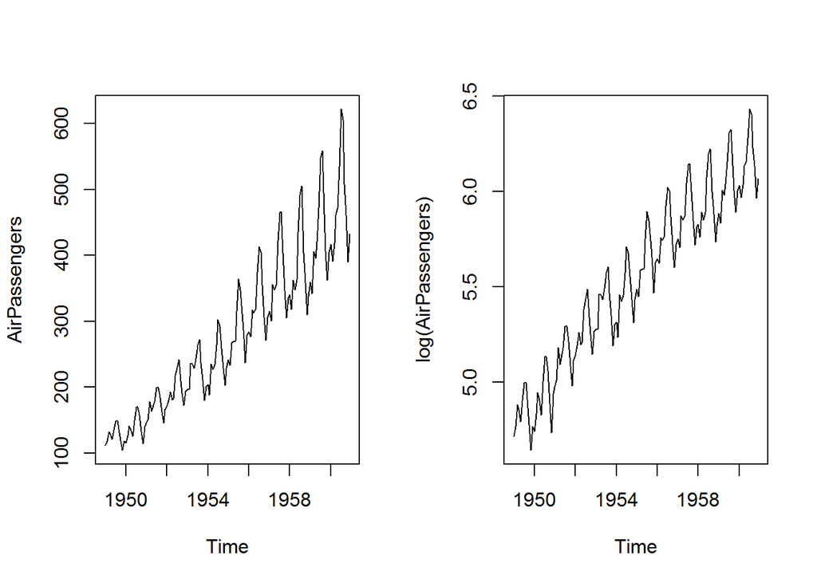

```r
# decompose the time series to trend, seasonal, error component.
opar <- par(no.readonly = TRUE)  #then you can change the parametor of the par()
par(mfrow = c(1 , 2))
plot(AirPassengers) # show the data of airpassengers
AirPassengers.log <- log(AirPassengers)
plot(AirPassengers.log , ylab = "log(AirPassengers)")
```

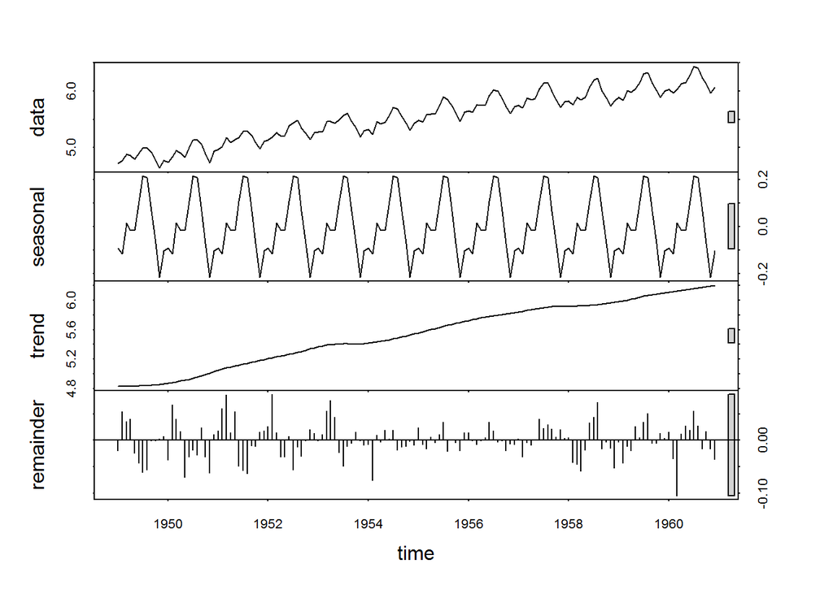

```r
par(opar)
fit <- stl(AirPassengers.log , s.window = "periodic")
plot(fit)
```

```r
fit$time.series
```

```
##             seasonal    trend     remainder
## Jan 1949 -0.09164042 4.829389 -0.0192493585
## Feb 1949 -0.11402828 4.830368  0.0543447685
## Mar 1949  0.01586585 4.831348  0.0355884457
## Apr 1949 -0.01402759 4.833377  0.0404632511
## May 1949 -0.01502478 4.835406 -0.0245905300
## Jun 1949  0.10978976 4.838166 -0.0426814256
## Jul 1949  0.21640041 4.840927 -0.0601151688
## Aug 1949  0.20960587 4.843469 -0.0558624690
## Sep 1949  0.06747156 4.846011 -0.0008273977
## Oct 1949 -0.07024836 4.850883 -0.0015112948
## Nov 1949 -0.21352774 4.855756  0.0021630667
## Dec 1949 -0.10063625 4.864586  0.0067346600
## Jan 1950 -0.09164042 4.873417 -0.0368443057
## Feb 1950 -0.11402828 4.883282  0.0670284530
## Mar 1950  0.01586585 4.893147  0.0397474219
## Apr 1950 -0.01402759 4.903156  0.0161459950
## May 1950 -0.01502478 4.913166 -0.0698276070
## Jun 1950  0.10978976 4.925404 -0.0312477713
## Jul 1950  0.21640041 4.937643 -0.0182444833
## Aug 1950  0.20960587 4.954420 -0.0282273969
## Sep 1950  0.06747156 4.971197  0.0239260449
## Oct 1950 -0.07024836 4.991662 -0.0310647612
## Nov 1950 -0.21352774 5.012127 -0.0624008823
## Dec 1950 -0.10063625 5.031094  0.0111846224
## Jan 1951 -0.09164042 5.050061  0.0183131352
## Feb 1951 -0.11402828 5.065044  0.0596196836
## Mar 1951  0.01586585 5.080027  0.0858909418
## Apr 1951 -0.01402759 5.093932  0.0138460280
## May 1951 -0.01502478 5.107837  0.0546824937
## Jun 1951  0.10978976 5.121064 -0.0490698826
## Jul 1951  0.21640041 5.134291 -0.0573861680
## Aug 1951  0.20960587 5.146131 -0.0624323009
## Sep 1951  0.06747156 5.157972 -0.0105077415
## Oct 1951 -0.07024836 5.169854 -0.0120089320
## Nov 1951 -0.21352774 5.181735  0.0153990463
## Dec 1951 -0.10063625 5.194803  0.0178207135
## Jan 1952 -0.09164042 5.207871  0.0254326447
## Feb 1952 -0.11402828 5.220493  0.0864920261
## Mar 1952  0.01586585 5.233115  0.0137094563
```

[output cut: 90 more lines]

```
## Oct 1959 -0.07024836 6.084145 -0.0050832771
## Nov 1959 -0.21352774 6.092156  0.0130161013
## Dec 1959 -0.10063625 6.100500  0.0040231864
## Jan 1960 -0.09164042 6.108844  0.0158822334
## Feb 1960 -0.11402828 6.117934 -0.0351985510
## Mar 1960  0.01586585 6.127024 -0.1050193083
## Apr 1960 -0.01402759 6.135814  0.0116112609
## May 1960 -0.01502478 6.144604  0.0273994037
## Jun 1960  0.10978976 6.152986  0.0194908174
## Jul 1960  0.21640041 6.161368  0.0551717057
## Aug 1960  0.20960587 6.170124  0.0271500533
## Sep 1960  0.06747156 6.178880 -0.0158702714
## Oct 1960 -0.07024836 6.187594  0.0160525773
## Nov 1960 -0.21352774 6.196307 -0.0166330133
## Dec 1960 -0.10063625 6.204752 -0.0356905175
```

```r
exp(fit$time.series)  #change back to the origin number
```

```
##           seasonal    trend remainder
## Jan 1949 0.9124332 125.1344 0.9809347
## Feb 1949 0.8922327 125.2571 1.0558486
## Mar 1949 1.0159924 125.3798 1.0362293
## Apr 1949 0.9860703 125.6345 1.0412930
## May 1949 0.9850875 125.8897 0.9757094
## Jun 1949 1.1160434 126.2377 0.9582166
## Jul 1949 1.2415994 126.5866 0.9416561
## Aug 1949 1.2331919 126.9088 0.9456692
## Sep 1949 1.0697998 127.2318 0.9991729
## Oct 1949 0.9321623 127.8533 0.9984898
## Nov 1949 0.8077298 128.4777 1.0021654
## Dec 1949 0.9042619 129.6173 1.0067574
## Jan 1950 0.9124332 130.7670 0.9638262
## Feb 1950 0.8922327 132.0634 1.0693259
## Mar 1950 1.0159924 133.3726 1.0405479
## Apr 1950 0.9860703 134.7143 1.0162770
## May 1950 0.9850875 136.0695 0.9325546
## Jun 1950 1.1160434 137.7450 0.9692354
## Jul 1950 1.2415994 139.4411 0.9819209
## Aug 1950 1.2331919 141.8003 0.9721673
## Sep 1950 1.0697998 144.1995 1.0242146
## Oct 1950 0.9321623 147.1809 0.9694128
## Nov 1950 0.8077298 150.2239 0.9395062
## Dec 1950 0.9042619 153.1004 1.0112474
## Jan 1951 0.9124332 156.0320 1.0184818
## Feb 1951 0.8922327 158.3874 1.0614328
## Mar 1951 1.0159924 160.7784 1.0896875
## Apr 1951 0.9860703 163.0296 1.0139423
## May 1951 0.9850875 165.3124 1.0562052
## Jun 1951 1.1160434 167.5135 0.9521146
## Jul 1951 1.2415994 169.7439 0.9442294
## Aug 1951 1.2331919 171.7657 0.9394767
## Sep 1951 1.0697998 173.8116 0.9895473
## Oct 1951 0.9321623 175.8891 0.9880629
## Nov 1951 0.8077298 177.9914 1.0155182
## Dec 1951 0.9042619 180.3327 1.0179804
## Jan 1952 0.9124332 182.7047 1.0257588
## Feb 1952 0.8922327 185.0254 1.0903427
## Mar 1952 1.0159924 187.3755 1.0138039
```

[output cut: 90 more lines]

```
## Oct 1959 0.9321623 438.8444 0.9949296
## Nov 1959 0.8077298 442.3741 1.0131012
## Dec 1959 0.9042619 446.0808 1.0040313
## Jan 1960 0.9124332 449.8186 1.0160090
## Feb 1960 0.8922327 453.9261 0.9654137
## Mar 1960 1.0159924 458.0711 0.9003071
## Apr 1960 0.9860703 462.1153 1.0116789
## May 1960 0.9850875 466.1952 1.0277782
## Jun 1960 1.1160434 470.1191 1.0196820
## Jul 1960 1.2415994 474.0762 1.0567220
## Aug 1960 1.2331919 478.2454 1.0275220
## Sep 1960 1.0697998 482.4514 0.9842550
## Oct 1960 0.9321623 486.6737 1.0161821
## Nov 1960 0.8077298 490.9329 0.9835046
## Dec 1960 0.9042619 495.0963 0.9649389
```

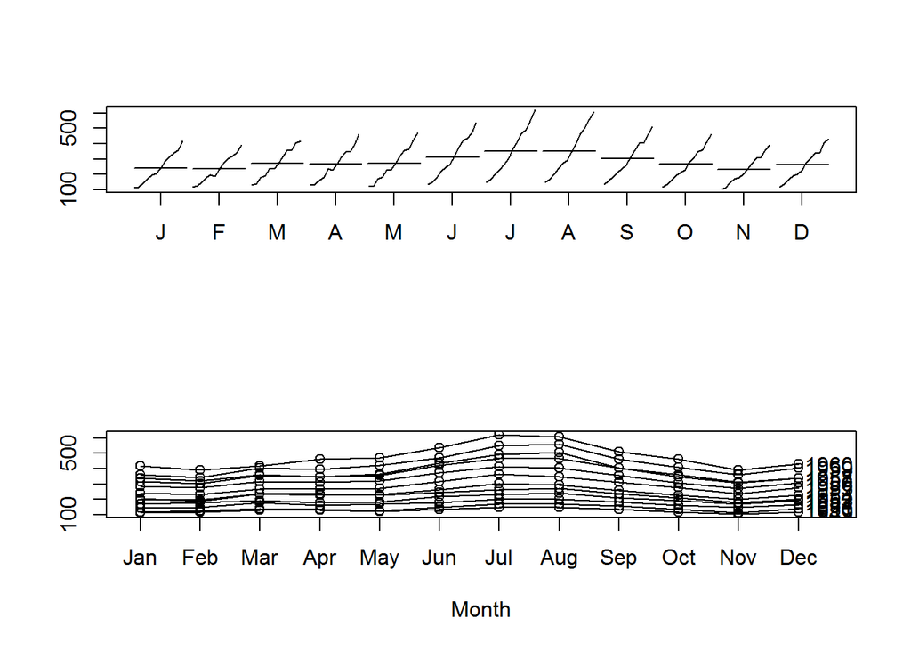

```r
# visulize the decomposing result
par(mfrow = c(2 , 1))
library(forecast)
monthplot(AirPassengers , xlab = "" , ylab = "")
seasonplot(AirPassengers , year.labels = "TRUE" , main = "")
```

# 指数模型

```r
# simple/single exponential model
library(forecast)
fit <- ets(nhtemp , model = "ANN")
fit
```

```
## ETS(A,N,N)
##
## Call:
##  ets(y = nhtemp, model = "ANN")
##
##   Smoothing parameters:
##     alpha = 0.1819
##
##   Initial states:
##     l = 50.2762
##
##   sigma:  1.1455
##
##      AIC     AICc      BIC
## 265.9298 266.3584 272.2129
```

```r
forecast(fit , 1)
```

```
##      Point Forecast    Lo 80    Hi 80    Lo 95    Hi 95
## 1972       51.87031 50.40226 53.33835 49.62512 54.11549
```

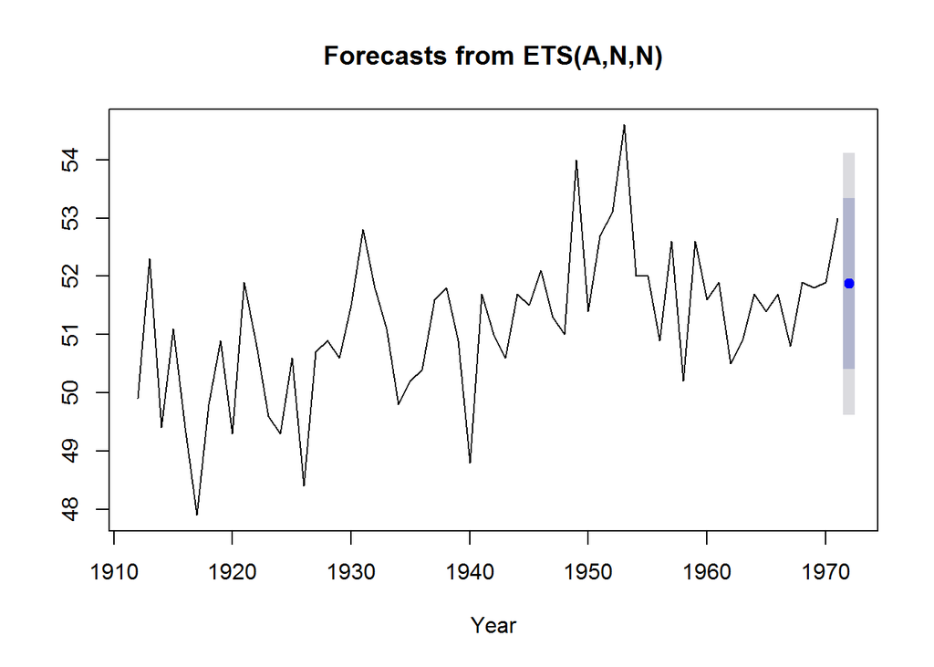

```r
plot(forecast(fit , 1) , xlab = "Year")
```

```r
accuracy(fit)
```

```
##                     ME     RMSE       MAE       MPE   MAPE      MASE
## Training set 0.1460657 1.126268 0.8951225 0.2419373 1.7489 0.7512408
##                      ACF1
## Training set -0.006441923
```

## 三次指数平滑法(Holt-Winters)

```r
# triple exponential model
library(forecast)
library(ggplot2)
par(mfrow = c(2 , 2))
# plot(AirPassengers)
AirPassengers.log = log(AirPassengers)
plot(AirPassengers.log)
fit <- ets(log(AirPassengers) , model = "AAA") #fit the triple exponential model
fit
```

```
## ETS(A,A,A)
##
## Call:
##  ets(y = log(AirPassengers), model = "AAA")
##
##   Smoothing parameters:
##     alpha = 0.6975
##     beta  = 0.0031
##     gamma = 1e-04
##
##   Initial states:
##     l = 4.7925
##     b = 0.0111
##     s = -0.1045 -0.2206 -0.0787 0.0562 0.2049 0.2149
##            0.1146 -0.0081 -0.0059 0.0225 -0.1113 -0.0841
##
##   sigma:  0.0383
##
##       AIC      AICc       BIC
## -207.1694 -202.3123 -156.6826
```

```r
accuracy(fit)
```

```
##                        ME       RMSE        MAE         MPE      MAPE
## Training set -0.001830684 0.03606976 0.02770885 -0.03435608 0.5079142
##                   MASE       ACF1
## Training set 0.2289192 0.05590461
```

```r
pred <- forecast(fit , 5)
plot(pred, main = "forecast for air travel" , ylab = "Log(AirPassengers)" , xlab = "Time" , xlim = c(1949, 1961))
par(new = TRUE)
plot(pred$fitted, xlim = c(1949, 1961), ylab = "Log(AirPassengers)")

pred$mean <- exp(pred$mean)
pred$lower <- exp(pred$lower)
pred$upper <- exp(pred$upper)
p <- cbind(pred$mean , pred$lower , pred$upper)
dimnames(p)[[2]] <- c("mean" , "Lo 80" , "Lo 95" , "Hi 80" , "Hi 95")
p
```

```
##              mean    Lo 80    Lo 95    Hi 80    Hi 95
## Jan 1961 450.0395 428.5065 417.5279 472.6544 485.0826
## Feb 1961 442.5448 416.8301 403.8280 469.8459 484.9735
## Mar 1961 511.1312 477.0088 459.8775 547.6945 568.0971
## Apr 1961 501.9652 464.6289 446.0019 542.3017 564.9506
## May 1961 506.1001 464.9691 444.5667 550.8694 576.1504
```

```r
# try to train model without transfer data to log
# str(pred)
```

[figure not shown]

# 自动选择模型,并训练模型来进行预测

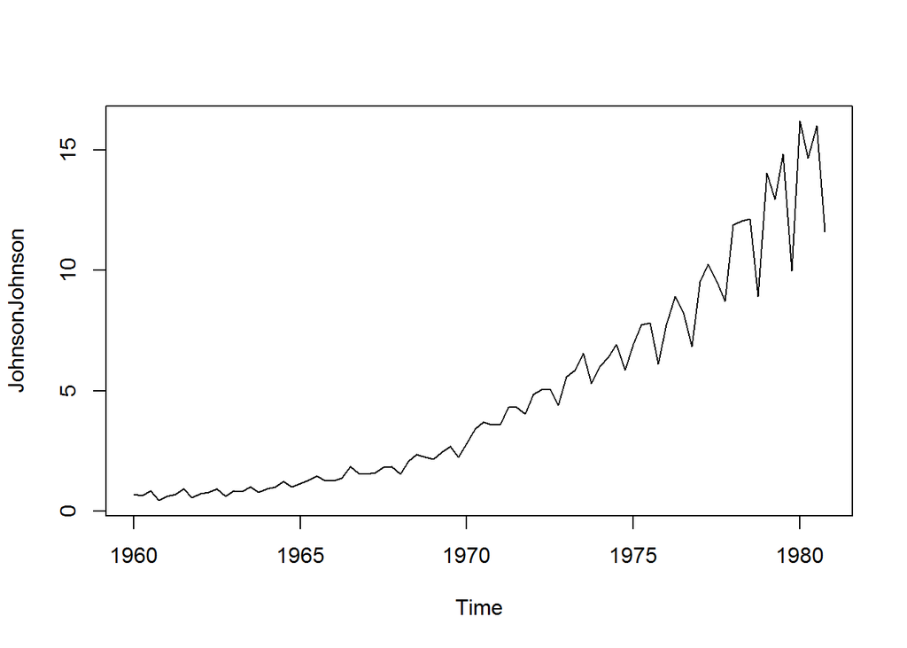

```r
# auto select the best model based on the function ets()
library(forecast)
plot(JohnsonJohnson)
```

```r
par(mfrow = c(1 , 2))
fit <- ets(JohnsonJohnson)  #auto get the model based on the func ets()
fit
```

```
## ETS(M,A,A)
##
## Call:
##  ets(y = JohnsonJohnson)
##
##   Smoothing parameters:
##     alpha = 0.2776
##     beta  = 0.0636
##     gamma = 0.5867
##
##   Initial states:
##     l = 0.6276
##     b = 0.0165
##     s = -0.2293 0.1913 -0.0074 0.0454
##
##   sigma:  0.0921
##
##      AIC     AICc      BIC
## 163.6392 166.0716 185.5165
```

```r
plot(forecast(fit) , main = "Johnson & Johnson Forecasts" , ylab = "Quarterly Earning (Dollars)" , xlab = "Time" ,
     flty = 2)

# mannually set model, and compare it with the automatic setting
fit.manual <- ets(JohnsonJohnson , model = "MMM")  #auto get the model based on the func ets()
fit.manual
```

```
## ETS(M,M,M)
##
## Call:
##  ets(y = JohnsonJohnson, model = "MMM")
##
##   Smoothing parameters:
##     alpha = 0.2195
##     beta  = 0.0341
##     gamma = 0.5675
##
##   Initial states:
##     l = 0.625
##     b = 1.0265
##     s = 0.698 1.2702 0.978 1.0539
##
##   sigma:  0.0906
##
##      AIC     AICc      BIC
## 164.0222 166.4546 185.8995
```

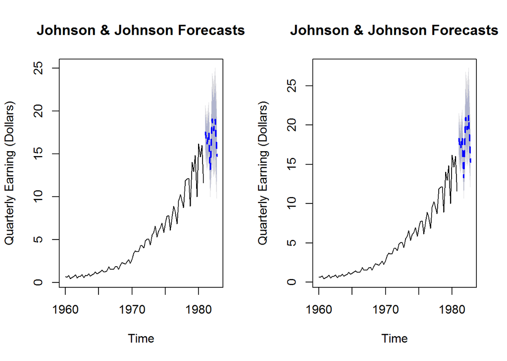

```r
plot(forecast(fit.manual) , main = "Johnson & Johnson Forecasts" , ylab = "Quarterly Earning (Dollars)" , xlab = "Time" ,
     flty = 2)
```